# Introducción a la Teoría de Grafos

Fernando Pérez (fperezgarciagm@gmail.com)

### Inicialización

A lo largo del siguiente curso utilizaremos fundamentalmente la librería iGraph de R. http://igraph.org/r/

*NOTA:* Actualizar la variable workingDir de acuerdo al directorio específico de cada alumno.

```r
library(igraph)
workingDir <- '/Users/fernando_perez/Documents/workspace_R/Master_IBM/data'
```

# 1. Introducción

## Crear un grafo definiendo directamente sus Vértices y Enlaces

Podemos definir un grafo como dos conjuntos (dafa.frames):

- Nodos
- Enlaces

Con la posibilidad de añadir propiedades adicionales. (p.e. población, distancia, …)

```r
cities <- data.frame(name = c("Almería", "Granada", "Jaén", "Madrid", "Málaga", "Murcia"),
                     population = c(192070, 237540, 115837, 3165000, 566913, 439712))

relations <- data.frame(from = c("Almería", "Almería", "Granada", "Jaén",   "Jaén",   "Madrid"),
                        to   = c("Granada", "Murcia",  "Jaén",    "Madrid", "Málaga", "Murcia"),
                        distance = c(167, 217, 92, 332, 202, 399))

g <- graph.data.frame(relations, directed=FALSE, vertices=cities)
```

Propiedades del grafo generado:

```r
print(g)
```

```
## IGRAPH UN-- 6 6 --
## + attr: name (v/c), population (v/n), distance (e/n)
```

```r
get.vertex.attribute(g, name = "population")
```

```
## [1]  192070  237540  115837 3165000  566913  439712
```

```r
get.edge.attribute(g, name = "distance")
```

```
## [1] 167 217  92 332 202 399
```

```r
get.edgelist(g)
```

```
##      [,1]      [,2]
## [1,] "Almería" "Granada"
## [2,] "Almería" "Murcia"
## [3,] "Granada" "Jaén"
## [4,] "Jaén"    "Madrid"
## [5,] "Jaén"    "Málaga"
## [6,] "Madrid"  "Murcia"
```

Representación simple del grafo

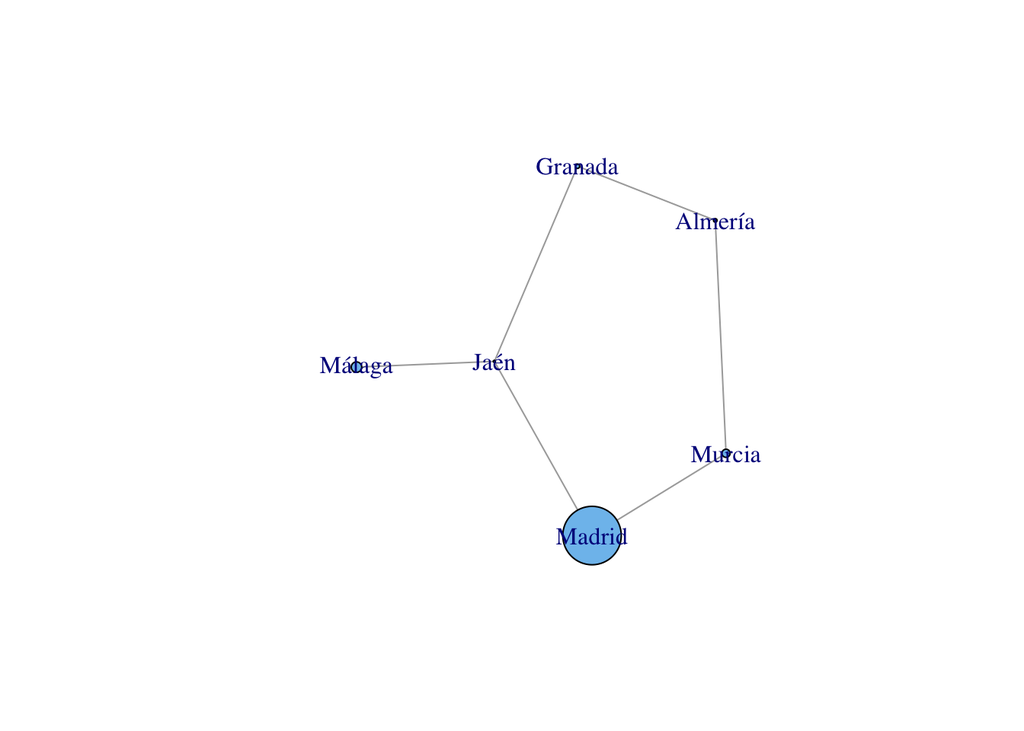

```r
plot.igraph(g,
     vertex.label = V(g)$name,
     vertex.size = V(g)$population/10^5)
```

Una vez finalizado el trabajo de generación de un grafo, podemos exportarlo para su utilización posterior, en multitud de formatos como:

- edgelist
- gml
- graphml
- pajek
- …

mediante la sentencia: write.graph(graph = g,file = “./graph.gml”, format = “gml”)

## Crear un grafo a través de su matriz de adyacencia

Podemos crear un grafo directamente a través de su matriz de adyacencia

```r
getwd()
```

```
## [1] "/Users/fernando_perez/Documents/workspace_R/Master_IBM"
```

```r
dat <- read.csv(file.path(workingDir, "cities.csv"), header=TRUE, row.names=1)
mat <- as.matrix(dat)

mat
```

```
##         Almería Granada Jaén Madrid Málaga Murcia
## Almería       0       1    0      0      0      1
## Granada       1       0    1      0      0      0
## Jaén          0       1    0      1      1      0
## Madrid        0       0    1      0      0      1
## Málaga        0       0    1      0      0      0
## Murcia        1       0    0      1      0      0
```

```r
g <- graph.adjacency(mat, mode="undirected", weighted = NULL)
print(g)
```

```
## IGRAPH UN-- 6 6 --
## + attr: name (v/c)
```

*La operacion inversa*

Podemos recuperar los nodos y enlaces de un grafo y convertirlos en data frames mediante

```r
get.data.frame(g, what="vertices")
```

```
##            name
## Almería Almería
## Granada Granada
## Jaén       Jaén
## Madrid   Madrid
## Málaga   Málaga
## Murcia   Murcia
```

```r
get.data.frame(g, what="edges")
```

```
##      from      to
## 1 Almería Granada
## 2 Almería  Murcia
## 3 Granada    Jaén
## 4    Jaén  Madrid
## 5    Jaén  Málaga
## 6  Madrid  Murcia
```

## Caminos de longitud n entre 2 nodos

Las sucesivas potencias de la matriz de adyacencia, proporcionan el número cadenas que unen 2 nodos, de longitud equivalente a la correspondiente potencia

Cadenas de longitud 2

```
##         Almería Granada Jaén Madrid Málaga Murcia
## Almería       2       0    1      1      0      0
## Granada       0       2    0      1      1      1
## Jaén          1       0    3      0      0      1
## Madrid        1       1    0      2      1      0
## Málaga        0       1    0      1      1      0
## Murcia        0       1    1      0      0      2
```

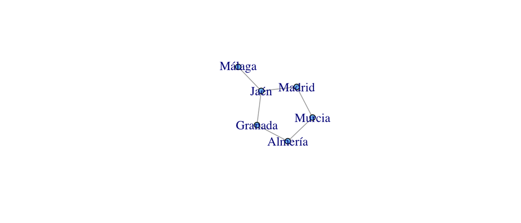

y Cadenas de longitud 3

```
##         Almería Granada Jaén Madrid Málaga Murcia
## Almería       0       3    1      1      1      3
## Granada       3       0    4      1      0      1
## Jaén          1       4    0      4      3      1
## Madrid        1       1    4      0      0      3
## Málaga        1       0    3      0      0      1
## Murcia        3       1    1      3      1      0
```

## Árboles, Estrellas y Grafos completos

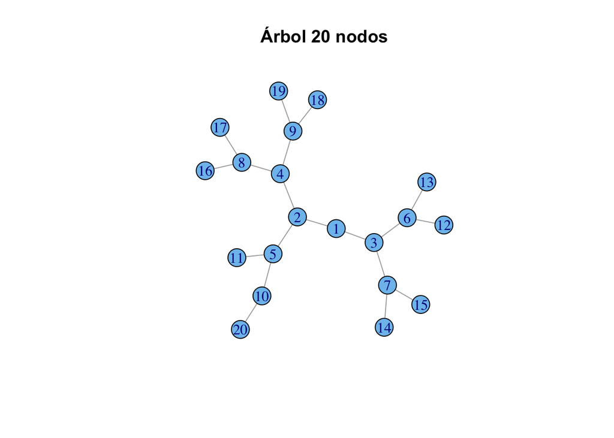

```r
g <- graph.tree(n = 20, children = 2, mode = "undirected")
plot(g, main = "Árbol 20 nodos")
```

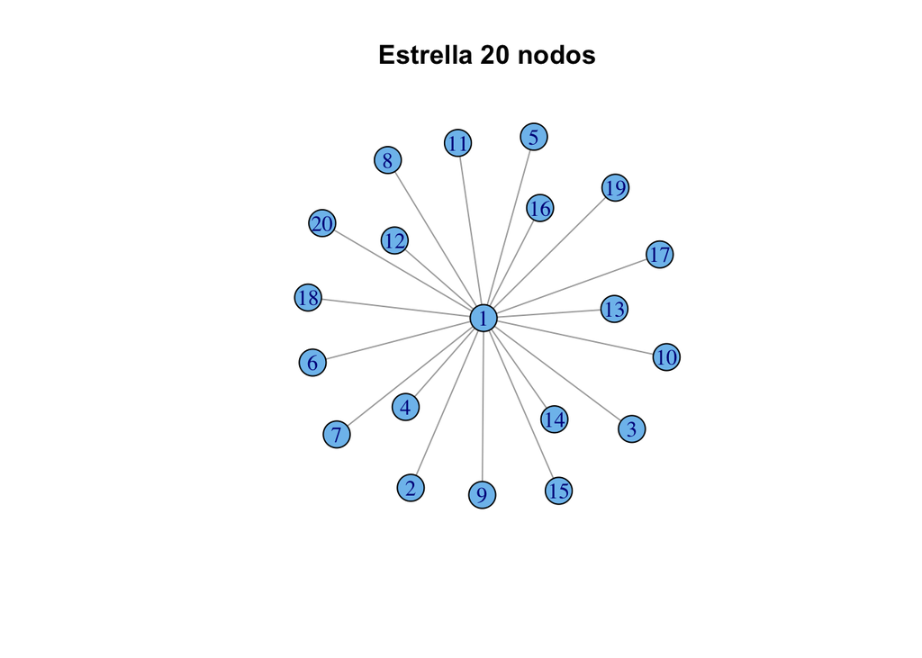

```r
g <- graph.star(n = 20, mode = "undirected")
plot(g, main = "Estrella 20 nodos")
```

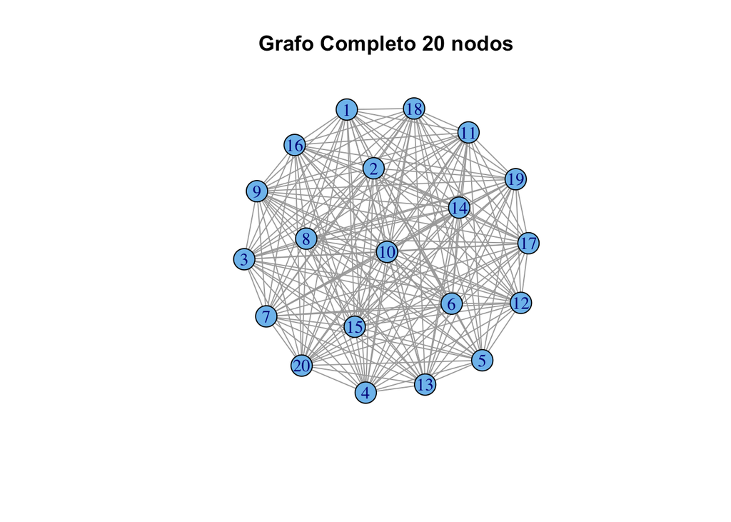

```r
g <- graph.full (n = 20, directed = FALSE, loops = FALSE)
plot(g, main = "Grafo Completo 20 nodos")
```

# 2. Métricas y Medidas

## Eigen Centrality

Para demostrar la Eigen Centrality vamos a crear 2 estrellas

```r
g1 <- graph.star(n = 6, mode = "undirected")
V(g1)$name <- (letters[1:6])

g2 <- graph.star(n = 8, mode = "undirected")
V(g2)$name <- (letters[7:14])
```

y las unimos por sus nodos centrales a través de un nuevo nodo “z”

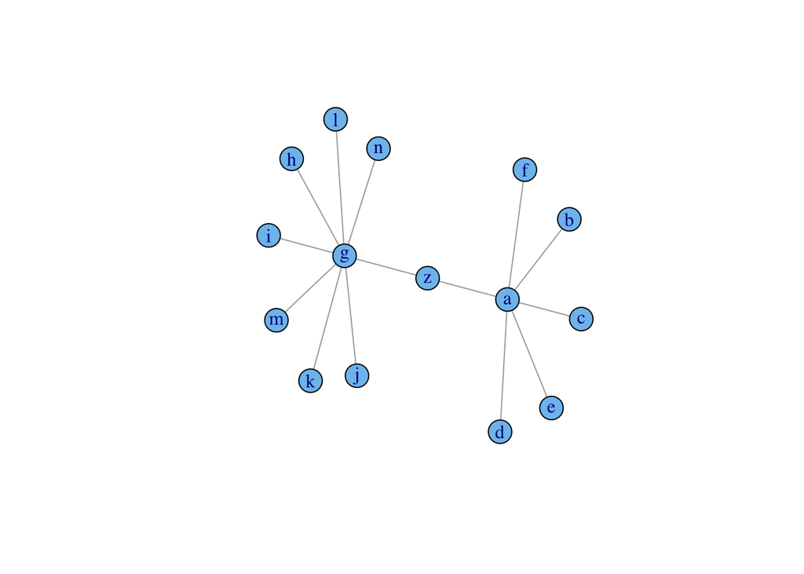

```r
g3 <- g1 %u% g2
g3 <- g3 + vertices("z")
g3 <- add.edges(g3,
        c(grep(V(g3)$name, pattern = "a"), grep(V(g3)$name, pattern = "z"),
          grep(V(g3)$name, pattern = "g"), grep(V(g3)$name, pattern = "z")))
plot(g3)
```

Obsérvese la diferencia entre las centralidades por Grado y Eigenvector:

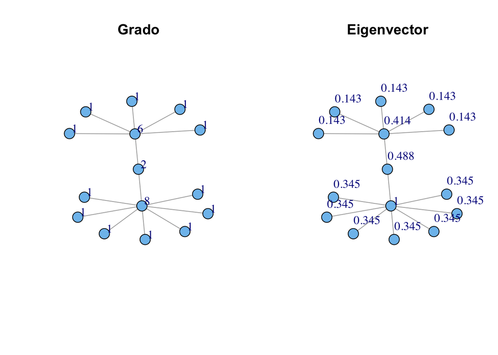

```r
par(mfrow = c(1, 2))
#Plotear por grado
V(g3)$degree <- degree(g3)

l <- layout.kamada.kawai(g3)
plot(g3, layout = l,
     vertex.label = V(g3)$degree,
     vertex.label.dist=1.5,
     main = "Grado")

#Plotear por EigenVector
V(g3)$evcent <- round(evcent(g3)$vector,3)

plot(g3, layout = l,
     vertex.label = V(g3)$evcent,
     vertex.label.dist=1.5,
     main = "Eigenvector")
```

```r
par(mfrow = c(1, 1))
```

### Con el ejemplo de las ciudades

**Eigenvector por matriz de adyacencia**

Seleccionar el autovector de la matriz de adyacencia con el mayor autovalor con todos sus elementos >0 o <0

```r
dat <- read.csv(file.path(workingDir, "cities.csv"), header=TRUE, row.names=1)
mat <- as.matrix(dat)

eigen(mat)
```

```
## $values
## [1]  2.1149075  1.0000000  0.6180340 -0.2541017 -1.6180340 -1.8608059
##
## $vectors
##            [,1]          [,2]          [,3]       [,4]          [,5]
## [1,] -0.3851210  5.000000e-01 -3.717480e-01  0.2795163  6.015010e-01
## [2,] -0.4293744 -4.052314e-15 -6.015010e-01 -0.3505418 -3.717480e-01
## [3,] -0.5229660 -5.000000e-01  3.330669e-15 -0.1904430  1.110223e-16
## [4,] -0.4293744  2.942091e-15  6.015010e-01 -0.3505418  3.717480e-01
## [5,] -0.2472761 -5.000000e-01  4.940492e-15  0.7494756  0.000000e+00
## [6,] -0.3851210  5.000000e-01  3.717480e-01  0.2795163 -6.015010e-01
##            [,6]
## [1,] -0.1534680
## [2,]  0.4390422
## [3,] -0.6635043
## [4,]  0.4390422
## [5,]  0.3565683
## [6,] -0.1534680
```

```r
maxEigenVal <- which.max(eigen(mat)$values)
cent1 <- eigen(mat)$vectors[,maxEigenVal]
cent1
```

```
## [1] -0.3851210 -0.4293744 -0.5229660 -0.4293744 -0.2472761 -0.3851210
```

**Contrastamos con la centralidad obtenida con igraph**

```r
g <- graph.adjacency(mat, mode="undirected", weighted = NULL)
V(g)$evcent <- evcent(g)$vector
V(g)$evcent
```

```
## [1] 0.7364170 0.8210368 1.0000000 0.8210368 0.4728339 0.7364170
```

```r
norm_vec <- function(x) sqrt(sum(x^2))

normEv <- norm_vec(V(g)$evcent)
cent2 <- V(g)$evcent / normEv

cbind(cent1,cent2)
```

```
##           cent1     cent2
## [1,] -0.3851210 0.3851210
## [2,] -0.4293744 0.4293744
## [3,] -0.5229660 0.5229660
## [4,] -0.4293744 0.4293744
## [5,] -0.2472761 0.2472761
## [6,] -0.3851210 0.3851210
```

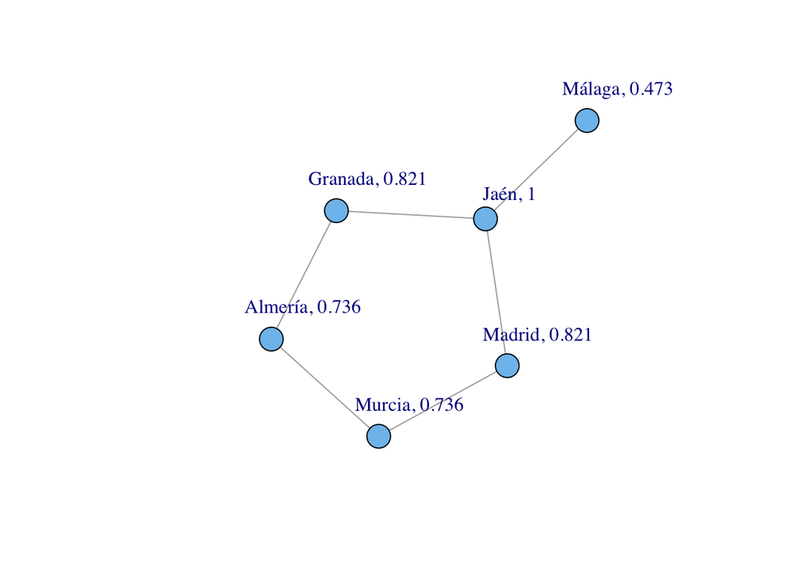

```r
plot(g, layout = layout.kamada.kawai,
     vertex.label = paste0(V(g)$name, ", ", round(V(g)$evcent, 3)),
     vertex.label.dist=1)
```

## Bonacich

A través de la función igraph **alpha.centrality**

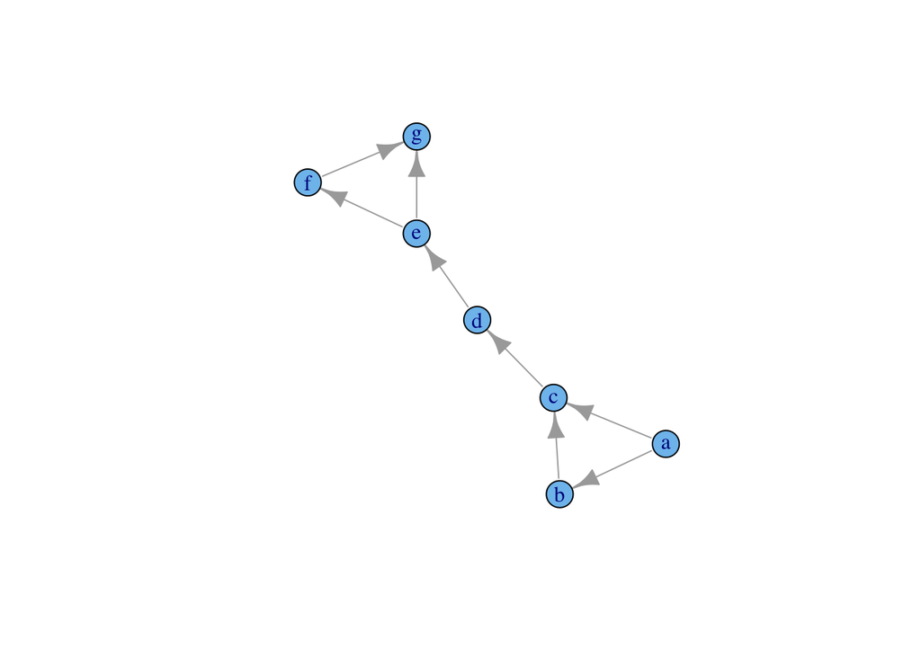

```r
g <- graph( c(1,2,
              1,3,
              2,3,
              3,4,
              4,5,
              5,6,
              5,7,
              6,7), directed = TRUE )

V(g)$name <- letters[1:7]

plot(g)
```

Calculamos 4 valores de alpha

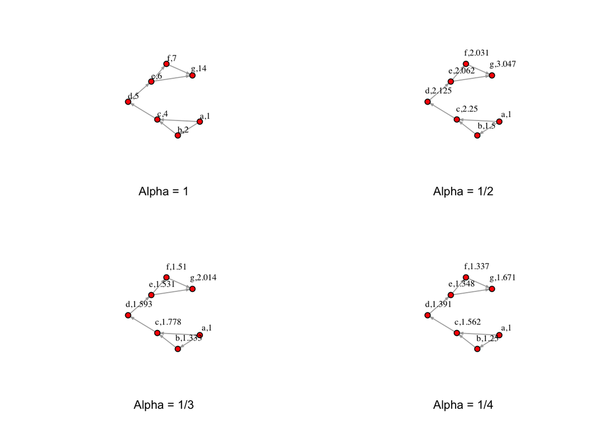

```r
V(g)$alphac1 <- round(alpha.centrality(g,alpha=1,loops = FALSE),3)
V(g)$alphac2 <- round(alpha.centrality(g,alpha=1/2),3)
V(g)$alphac3 <- round(alpha.centrality(g,alpha=1/3),3)
V(g)$alphac4 <- round(alpha.centrality(g,alpha=1/4),3)
```

## PageRank

A través de la función igraph **page.rank**

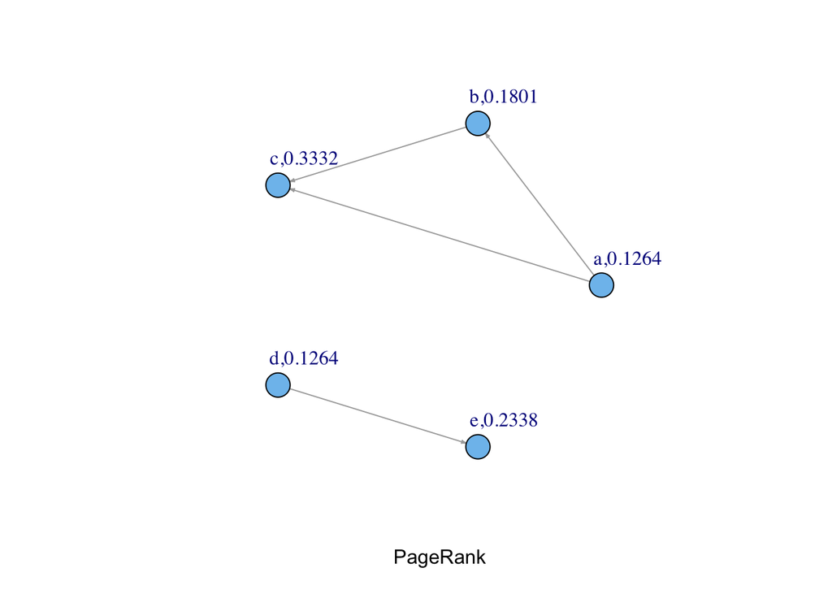

```r
g <- graph(n = 5,
           c(1,2,
             1,3,
             2,3,
             4,5), directed = TRUE )

V(g)$name <- letters[1:5]
V(g)$pr <- round(page.rank(g, damping = 0.85)$vector, 4)

plot(g, layout = layout.circle,
     xlab = "PageRank",
     vertex.label = paste(V(g)$name,V(g)$pr, sep = ","),
     edge.arrow.size=0.2,
     vertex.label.dist=1)
```

## Closeness Centrality

A través de la función igraph **closeness** Recuperamos el grafo anterior (eigenvector) y calculamos su *closeness* centrality

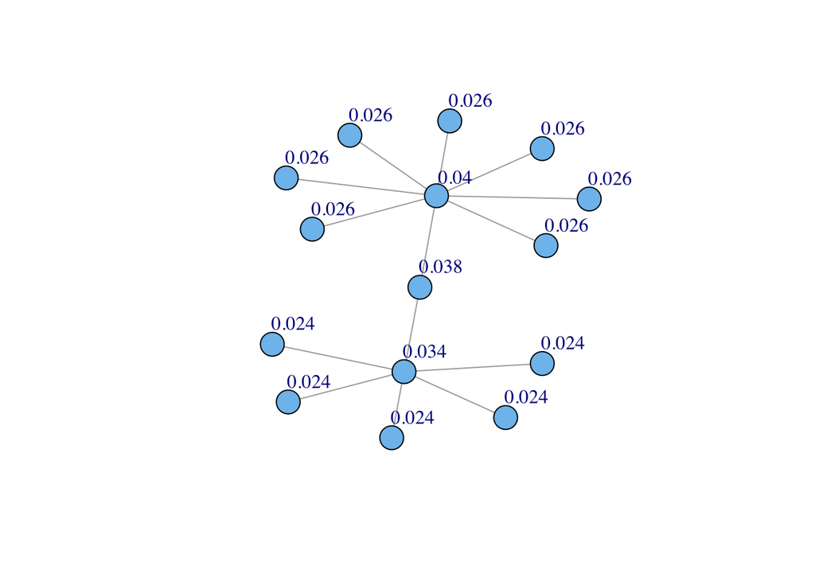

```r
V(g3)$closeness <- closeness(g3)

l <- layout.fruchterman.reingold(g3)
plot(g3, layout=l, vertex.label = round(V(g3)$closeness,3),
     vertex.label.dist=1)
```

## Betweenness

A través de la función igraph **betweenness**

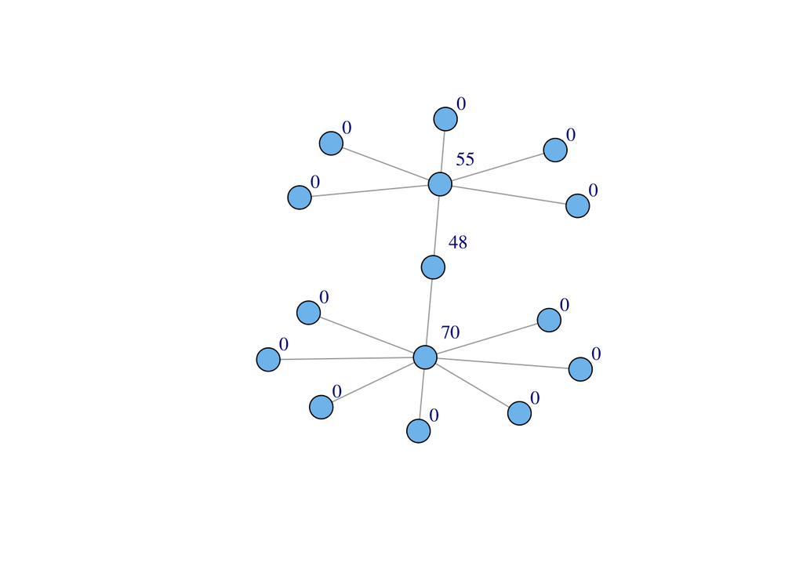

```r
V(g3)$betweennses <- betweenness(g3)

l <- layout.fruchterman.reingold(g3)
plot(g3, layout=l, vertex.label = round(V(g3)$betweennses,3),
     vertex.label.dist=2)
```

# 3. Grupos de nodos

## Distribuciones de grado

Vamos a comparar la distribución de grado en 3 tipos de grafos completamente diferentes, todos ellos con 100 nodos:

- Anillo, Todos los nodos con el mismo grado
- Aleatorio con probabilidad del 10%
- Red libre de escala

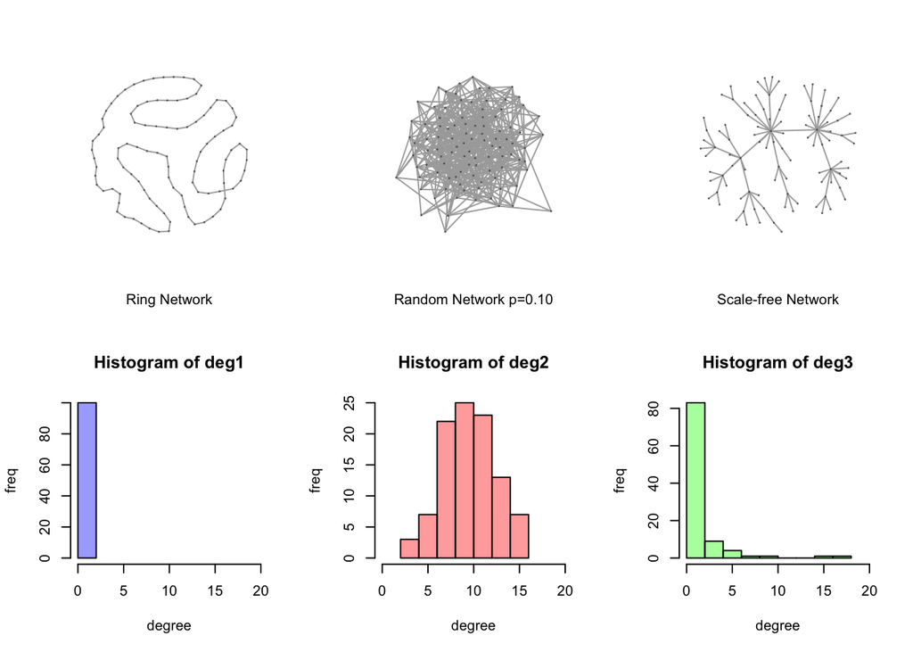

```r
n = 100
g1 <- graph.ring(n)
g2 <- erdos.renyi.game(n, 0.10)
g3 <- barabasi.game(n)

deg1 <- degree(g1)
deg2 <- degree(g2)
deg3 <- degree(g3)
```

## Power Law

A continuación revisamos las distribuciones Power Law, típicas en las redes libres de escala, para lo cual generamos una red de este tipo con 5000 nodos.

```r
library("poweRlaw")

g1 <- barabasi.game(n)
deg1 <- degree(g1)

#Crear la distribución
m = displ$new(deg1)

est = estimate_pars(m)
m$setPars(est)

m$pars
```

```
## [1] 2.294907
```

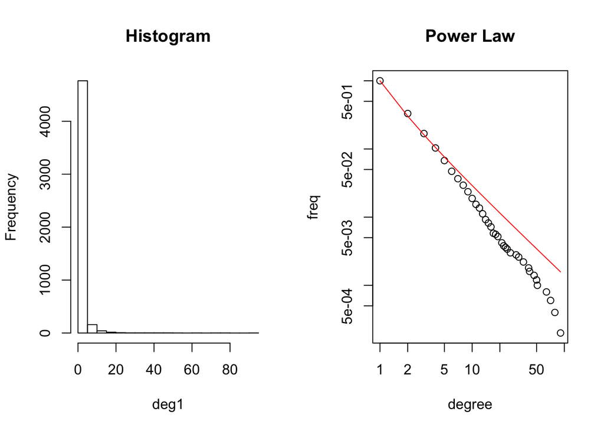

```r
degVal <- seq(1, max(deg1), by = 1)
freqDeg <- cbind("k" = degVal,
                 "freq" = unlist(lapply(degVal, function(x){
                                                    length(which(deg1 == x)) / n
                                                })),
                 "count" = unlist(lapply(degVal, function(x){
                                                    length(which(deg1 == x))
                                                }))
                 )

head(freqDeg, 10)
```

```
##        k   freq count
##  [1,]  1 0.6692  3346
##  [2,]  2 0.1626   813
##  [3,]  3 0.0648   324
##  [4,]  4 0.0358   179
##  [5,]  5 0.0206   103
##  [6,]  6 0.0104    52
##  [7,]  7 0.0072    36
##  [8,]  8 0.0058    29
##  [9,]  9 0.0048    24
## [10,] 10 0.0034    17
```

```r
tail(freqDeg, 10)
```

```
##        k  freq count
## [82,] 82 0e+00     0
## [83,] 83 0e+00     0
## [84,] 84 0e+00     0
## [85,] 85 0e+00     0
## [86,] 86 0e+00     0
## [87,] 87 0e+00     0
## [88,] 88 0e+00     0
## [89,] 89 0e+00     0
## [90,] 90 0e+00     0
## [91,] 91 2e-04     1
```

*Cálculo de los momentos de la distribución*

- Media

```r
m_ord1 <- sum(freqDeg[,1] * freqDeg[,2])
m_ord1
```

```
## [1] 1.9996
```

```r
weighted.mean(x = freqDeg[,1], w = freqDeg[,3])
```

```
## [1] 1.9996
```

```r
m_ord2 <- sum(freqDeg[,1]^2 * freqDeg[,2])
m_ord2
```

```
## [1] 15.7824
```

```r
weighted.mean(x = freqDeg[,1]^2, w = freqDeg[,3])
```

```
## [1] 15.7824
```

```r
m_ord3 <- sum(freqDeg[,1]^3 * freqDeg[,2])
m_ord3
```

```
## [1] 584.8468
```

# 4. Modelos de Grafos

## Erdos Renyi

Generación de una red aleatoria de 500 nodos, según el modelo E-R de G(n,p) y observación de sus diferentes *momentos* en función de la probabilidad de enlace.

- 1/n^2: la red tiene algunos enlace. Grado medio = 1/n
- 1/n^(3/2): La red tiene un componente de al menos 3 enlaces. Grado medio = 1/n^(1/2)
- 1/n: La red tiene un ciclo, comienzo del componente gigante. Grado medio = 1
- Log(n)/n. La red esta conectada. Grado medio = Log(n)

```r
p1 = 1/n^2
p2 = (1/n^(3/2))
p3 = 1/n
p4 = log(n)/n

#Forzamos las probabilidades ligeramente
p1 <- p1 * 1.10
p2 <- p2 * 1.10
p3 <- p3 * 1.10
p4 <- p4 * 1.10

er1 <- erdos.renyi.game(n, p1, type="gnp")
er2 <- erdos.renyi.game(n, p2, type="gnp")
er3 <- erdos.renyi.game(n, p3, type="gnp")
er4 <- erdos.renyi.game(n, p4, type="gnp")

deg1 <- degree(er1)
deg2 <- degree(er2)
deg3 <- degree(er3)
deg4 <- degree(er4)
```

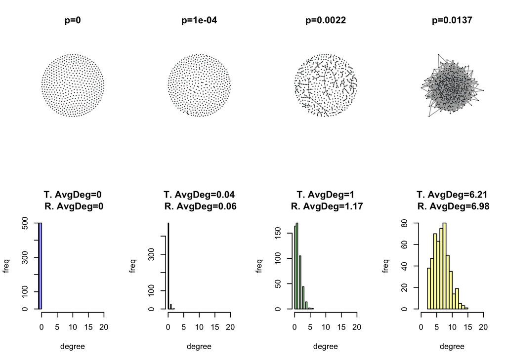

En este tipo de redes el Clustering Coefficient = c / (n-1)

```r
er1 <- erdos.renyi.game(n, 0.05, type="gnp")
deg1 <- degree(er1)

#teórico
mean(deg1) / (n-1)
```

```
## [1] 0.05058918
```

```r
#calculado
transitivity(er1)
```

```
## [1] 0.05163749
```

Podemos encontrar un simulador de redes de este tipo en https://fperezgarcia.shinyapps.io/shinyApp/

## Watts - Strogatz

Vamos a simular una red con efecto *Small World* a partir de una celosía en anillo donde cada nodo se une a sus vecinos de nivel 1 y 2

```r
n = 100
neighborhood = 2
g <- graph.ring(n, circular = TRUE)
g <- connect.neighborhood(g, neighborhood)
```

A continuación recolocamos los extremos de los enlaces con una probabilidad uniforme del 5%

```r
rewProb <- 0.05
g2 <- rewire.edges(g, prob = rewProb)
```

Observese la diferencia entre el ASP y el Clustering Coefficient en ambos casos:

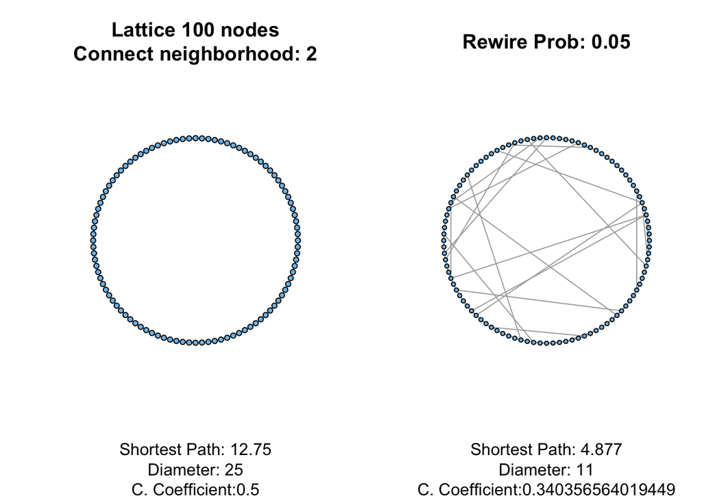

### Directamente con igraph

igraph incorpora la función **watts.strogatz.game** para generar directamente este tipo de grafos:

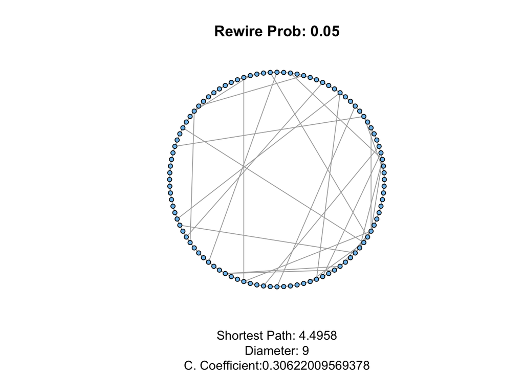

```r
g <- watts.strogatz.game(dim = 1, size = 100, nei = 2, p=0.05)
plot(g, layout = layout.circle(g), vertex.size = 4, vertex.label = NA,
     main = paste0("Rewire Prob: ", rewProb),
     sub  = paste0("Shortest Path: ", mean(shortest.paths(g)), "\n",
                   "Diameter: ", diameter(g), "\n",
                   "C. Coefficient:", transitivity(g)))
```

## Barabasi - Albert

Creamos una red con efecto *Preferential Attachment* a partir de un grafo completo de 3 nodos

A continuación iteramos 100 ciclos de forma que en cada ciclo se generan 2 nuevos nodos que se enlazan inicialmente a un nodo existente con una probabilidad proporcional a su grado.

Visualizamos una evolución de la red cada 10 ciclos, los 3 primeros nodos se colorean en rojo, para facilitar su localización:

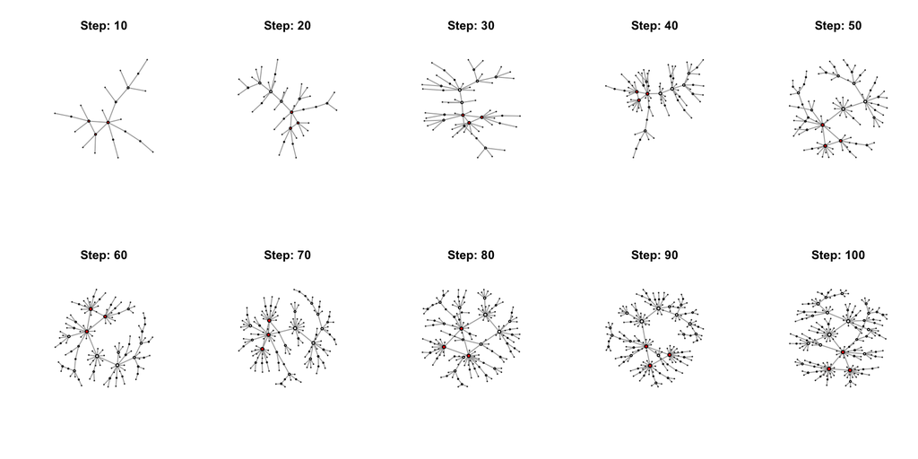

```r
#Parametrización
initNodes <- 3
newEdges <- 2
numLoops <- 100

#Cada cuantas iteraciones se realiza un plot
steps <- trunc(numLoops/10)

#Inicialización con un grafo completo, se marcan en rojo los nodos iniciales
g <- graph.full (n = initNodes, directed = FALSE, loops = FALSE)
V(g)$color <- "red"

par(mfrow = c(2, steps/2))

#Bucle de generación de grafos
for (i in seq(1,numLoops)){
    #Creamos una lista donde cada nodo aparece tantas veces como su grado
    V(g)$degree <- degree(g)
    mVertex <- get.data.frame(g, what = "vertices")
    mList <- list()
    for (j in seq(1,dim(mVertex)[1])){
        mList <- c(mList, rep(j, mVertex[j,"degree"]))
    }
    mList <- unlist(mList)

    #Para los nuevos nodos, elegir al azar un destino dentro de la lista de nodos por grado
    for (j in seq(1,newEdges)){
        edgeDest <- mList[round(runif(1,min = 1, max = length(mList)))]
        #Añadir el nodo
        g <- add.vertices(g, nv = 1)
        #Añadir el enlace entre el nuevo nodo y el elegido al azar
        g <- add.edges(g,edges = c(length(V(g)), edgeDest))
    }

    #Si el paso actual esta en el intervalo de pintado, generar el plot
    if (i%%steps == 0){
        deg <- degree(g)
        plot(g,
             vertex.label= NA,
             vertex.color = V(g)$color,
             edge.arrow.size=0.02,
             vertex.size = 1+2*log(deg),
             main = paste0("Step: ", i))
    }

}
```

### Directamente con igraph

igraph incorpora la función **barabasi.game** para generar directamente este tipo de grafos:

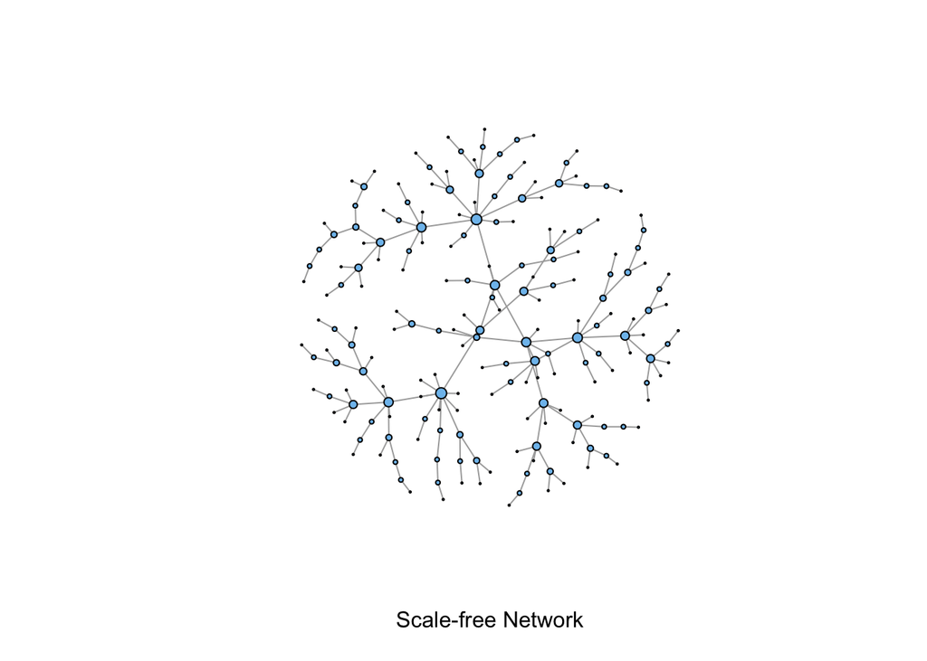

```r
initNodes <- 3
g <- graph.full (n = initNodes, directed = FALSE, loops = FALSE)
g4 <- barabasi.game(n = 200, m = 1, start.graph = g,
                    out.pref = TRUE, directed = FALSE)
deg <- degree(g4)
plot(g4,
     vertex.label= NA,
     vertex.color = V(g4)$color,
     edge.arrow.size=0.02,
     vertex.size = 1+2*log(deg),
     xlab = "Scale-free Network")
```